# A relação entre o IDHM e a votação presidencial de 2018 no estado de SP

Gustavo Casteletti de Alcântara

07/03/2022

## Introdução

Seguindo a proposta do Case, utilizei, através da [Base dos Dados](https://basedosdados.org/), a tabela dos resultados das Eleições Brasileiras por município disponível [aqui](https://basedosdados.org/dataset/br-tse-eleicoes). O acesso e utilização do pacote [basedosdados](https://basedosdados.github.io/mais/api_reference_r/) no Rstudio, o download e limpeza inicial (seleção, filtragem de atributos e criação de variáveis) encontram-se [aqui](https://github.com/gustavoalcantara/bd_eleicoes/blob/master/acessodatalake.R).

### DF de trabalho e outras proposições

Com o df pronto para uso, é válido ressaltar que a tabela inicial possuía cerca de 23M de linhas. Se fosse necessário o download deste arquivo em minha máquina, faria a seleção e limpeza dos dados atráves do datalake do Google pela regra SQL que elaborei. Visualize-a [aqui](https://console.cloud.google.com/bigquery?sq=52786671863:dca4197316d34aca8d3f63ef74044d34).

### Visualização do df

A tabela a seguir é o dataframe que iremos trabalhar de agora em diante. São um pouco mais de 9k linhas e 10 colunas ao total. Selecionei a votação presidencial para o estado de São Paulo no ano de 2018. Veja:

| X | ano | turno | sigla_uf | sigla_partido | id_municipio | votos | resultado | cargo | porcentagem |
| --- | --- | --- | --- | --- | --- | --- | --- | --- | --- |
| 1 | 2018 | 1 | SP | MDB | 3501103 | 35 | nao eleito | presidente | 0.6962403 |
| 2 | 2018 | 1 | SP | PATRIOTA | 3501103 | 13 | nao eleito | presidente | 0.2586035 |
| 3 | 2018 | 1 | SP | PDT | 3501103 | 115 | nao eleito | presidente | 2.2876467 |
| 4 | 2018 | 1 | SP | PPL | 3501103 | 2 | nao eleito | presidente | 0.0397852 |
| 5 | 2018 | 1 | SP | PSOL | 3501103 | 4 | nao eleito | presidente | 0.0795703 |
| 6 | 2018 | 1 | SP | PDT | 3501152 | 994 | nao eleito | presidente | 5.0771274 |

## Votação presidenciável no 1º Turno

A partir do df de trabalho, elaborei um gráfico simples de boxplot agrupando os municípios e a votação para cada partido:

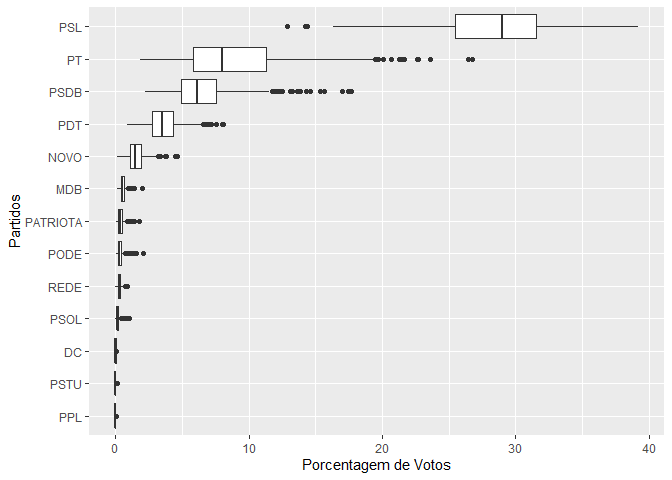

## O IDHM e sua relação com a votação

Como forma de trabalhar com mais de uma tabela ao mesmo tempo e realizar análises exploratórias que relacionam-se, é necessário ter em mente que um atributo ou mais que estejam presente nas tabelas sejam iguais. Assim, realizei um join (utilizando a biblioteca do dplyr) da tabela do IDHM disponível no site da [PNUD Brasil](https://www.br.undp.org/content/brazil/pt/home/idh0/rankings/idhm-municipios-2010.html) com a Id dos municipios de São Paulo. Porém, é necessário alterar o nome da variável ‘Cod.IBGE’ para ‘id_municipio’ para realizar o Join. Essa alteração deixei no script de manipulação dos dados [aqui](https://github.com/gustavoalcantara/bd_eleicoes/blob/master/script_de_testes.R).

| X | id_municipio | Município | idhm_2010 |
| --- | --- | --- | --- |
| 1 | 3500105 | Adamantina | 0.790 |
| 2 | 3500204 | Adolfo | 0.730 |
| 3 | 3500303 | Aguaí | 0.715 |
| 4 | 3500402 | Águas da Prata | 0.781 |
| 5 | 3500501 | Águas de Lindóia | 0.745 |
| 6 | 3500550 | Águas de Santa Bárbara | 0.757 |

### Join das tabelas

É necessário realizar a união dos dois dataframes. Para isso vou utilizar a função left_join() do dplyr. Veja essa função [aqui](https://github.com/gustavoalcantara/bd_eleicoes/blob/master/script_de_testes.R).

| id_municipio | votos | resultado | cargo | porcentagem | Município | idhm_2010 |
| --- | --- | --- | --- | --- | --- | --- |
| 3501103 | 35 | nao eleito | presidente | 0.6962403 | Alto Alegre | 0.700 |
| 3501103 | 13 | nao eleito | presidente | 0.2586035 | Alto Alegre | 0.700 |
| 3501103 | 115 | nao eleito | presidente | 2.2876467 | Alto Alegre | 0.700 |
| 3501103 | 2 | nao eleito | presidente | 0.0397852 | Alto Alegre | 0.700 |
| 3501103 | 4 | nao eleito | presidente | 0.0795703 | Alto Alegre | 0.700 |
| 3501152 | 994 | nao eleito | presidente | 5.0771274 | Alumínio | 0.766 |

## Análise do IDHM com a Porcentagem de voto

Índices são úteis para avaliar e compreender contextos diversos. É válido afirmar que o estudo do Índice de Desenvolvimento Humano Municipal é referencial de uma série de artigos, livros e discussões que relacionam-o com outras variáveis. Aqui propus relacioná-lo com a votação dos partidos nos municipios.Para isso, é necessário classificar o IDHM que varia de Muito Baixo até Muito Alto. Os municipios de São Paulo, em 2010, variam entre IDHM’s Médio à Muito Alto, [veja mais aqui](https://www.br.undp.org/content/brazil/pt/home/idh0/conceitos/o-que-e-o-idhm.html). Assim, classifiquei o IDHM dos municipios paulistas de acordo com a regra estabelecida e elaborei um gráfico simples para visualizar a relação entre os votos nos candidatos e o IDHM dos municípios.

### Classificação do IDHM

```r
dplyr::mutate(dadoseidhm,
              classificacao_idhm=case_when(
                idhm_2010<=0.699~'Medio',
    idhm_2010>=0.700 & idhm_2010<0.799~'Alto',
    idhm_2010>=0.800~'Muito Alto')) -> dadoseidhm
```

| porcentagem | Município | idhm_2010 | classificacao_idhm |
| --- | --- | --- | --- |
| 0.6962403 | Alto Alegre | 0.700 | Alto |
| 0.2586035 | Alto Alegre | 0.700 | Alto |
| 2.2876467 | Alto Alegre | 0.700 | Alto |
| 0.0397852 | Alto Alegre | 0.700 | Alto |
| 0.0795703 | Alto Alegre | 0.700 | Alto |
| 5.0771274 | Alumínio | 0.766 | Alto |

### Gráficos e Possíveis Análises

#### BoxPlot e relação com o IDHM por partidos no 1º Turno

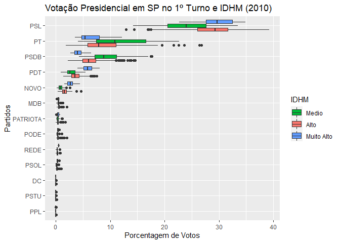

#### 2º Turno

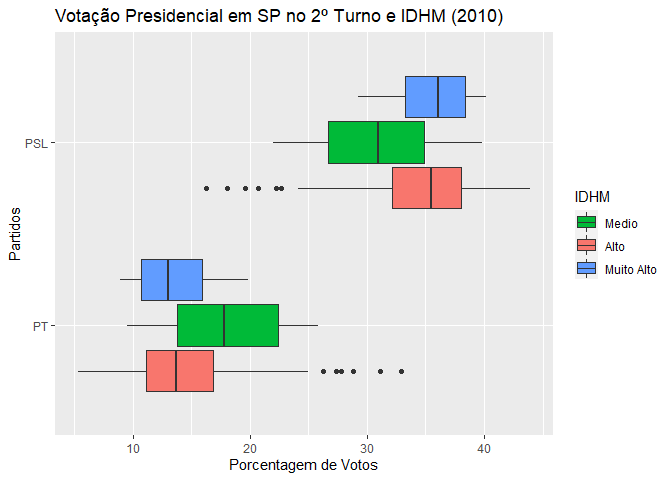

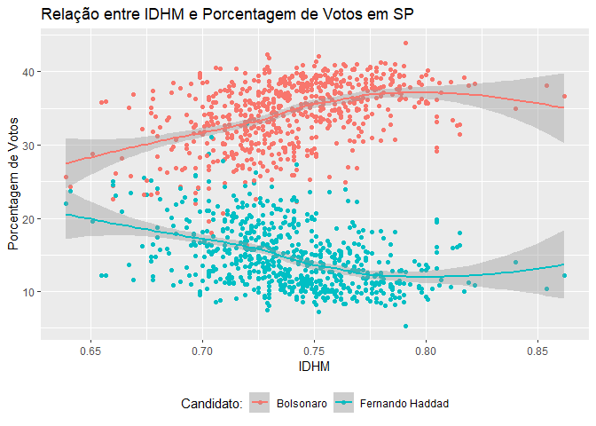

## Considerações

Este case é fruto de uma das etapas do processo seletivo da Base dos Dados. Aqui tentei relacionar uma tabela externa com uma base disponibilizada pela organização, além do acesso do datalake via RStudio. As interpretações dos gráficos aqui apresentados são diversas. Acredito que a principal seja a relação da baixa quantidade de votos de Fernando Haddad principalmente em municipios do estado de São Paulo classificados com alto IDHM. É fato que futuras análises possam emergir e outros bancos de dados serem adicionados para complexificar e criar novos insights. Assim, espero que tenha atendido às expectativas da instituição quanto à proposta. Fico Grato pela leitura deste material e futuro feedback. Muito obrigado.

## Referências

### Datasets

[Base dos Dados](https://github.com/basedosdados)

[Datalake das Eleições da Base dos Dados](https://basedosdados.org/dataset/br-tse-eleicoes)

[Atlas do Desenvolvimento Humano - PNUD](https://www.br.undp.org/content/brazil/pt/home/idh0/rankings/idhm-municipios-2010.html)

### Pacotes

[Tidyverse](https://www.tidyverse.org/)